# Insurance_Claim_Prediction

2023-11-15

Following are the necessary libraries imported

```r
library(ggplot2)
library(caret)
library(dplyr)
library(vip)
library(ranger)
library(rpart)
library(rpart.plot)
library(pROC)
library(xgboost)
library(Matrix)

options(warn = -1)
```

```r
#Reading the csv file
insurance.data.dup <- read.csv("~/Documents/GitHub/GitHub/Insurance-Claim-Prediction/data/insurance.csv")
insurance.data <- insurance.data.dup

str(insurance.data)
```

```
## 'data.frame':    1338 obs. of  8 variables:
##  $ age           : int  19 18 28 33 32 31 46 37 37 60 ...
##  $ sex           : int  0 1 1 1 1 0 0 0 1 0 ...
##  $ bmi           : num  27.9 33.8 33 22.7 28.9 ...
##  $ children      : int  0 1 3 0 0 0 1 3 2 0 ...
##  $ smoker        : int  1 0 0 0 0 0 0 0 0 0 ...
##  $ region        : int  3 2 2 1 1 2 2 1 0 1 ...
##  $ charges       : num  16885 1726 4449 21984 3867 ...
##  $ insuranceclaim: int  1 1 0 0 1 0 1 0 0 0 ...
```

```r
nrow(insurance.data)
```

```
## [1] 1338
```

There are total of 1338 observations with the explanatory variables such as age, sex, bmi, children, smoker, region, charges as well as the response variables such as insuranceclaim

#Data Preprocessing

Following code removes the duplicates from the data if there are any.

```r
insurance.data <- unique(insurance.data)
nrow(insurance.data)
```

```
## [1] 1337
```

Count of the data is 1337 after applying the unique function on the data.

```r
print("sex")
```

```
## [1] "sex"
```

```r
table(insurance.data$sex)
```

```
##
##   0   1
## 662 675
```

```r
print("children")
```

```
## [1] "children"
```

```r
table(insurance.data$children)
```

```
##
##   0   1   2   3   4   5
## 573 324 240 157  25  18
```

```r
print("smoker")
```

```
## [1] "smoker"
```

```r
table(insurance.data$smoker)
```

```
##
##    0    1
## 1063  274
```

```r
print("region")
```

```
## [1] "region"
```

```r
table(insurance.data$region)
```

```
##
##   0   1   2   3
## 324 324 364 325
```

Predictors variables Sex, children, smoker and region contians intermediate levels such as 2, 6, 2, 4 respectively. There are total of 662 females and 675 males. Total count of non smokers is 1063 when compared to the smokers of 274. There are total of 4 regions and their mapping is as follows northeast=0, northwest=1, southeast=2, southwest=3 with the count of 324, 324, 364 and 325 respectively. Children feature indicates the number of children or the dependent’s where as no dependents are 573, 1 dependent’s as 324, 2 dependent’s as 240, 3 dependent’s as 157, 4 dependents as 25 and 5 as 18.

```r
table(insurance.data$insuranceclaim)
```

```
##
##   0   1
## 555 782
```

Response variables posses two level such as 0 and 1 where o indicates the no claim and 1 indicates claim and their counts are 555 and 782 respectively.

Following displays the unique values of each explanatory variable

```r
sapply(insurance.data, function(x) unique(x))
```

[output not shown]

[output cut: 253 more lines]

Following code is to conver the columns sex, children, smoker, insuranceclaim and region columns to factor levels

```r
column_names <- c(
     "sex", "children", "smoker", "insuranceclaim", "region"
)

# Convert the selected columns to factors in your data frame
insurance.data[, column_names] <- lapply(insurance.data[, column_names], as.factor)

str(insurance.data)
```

```
## 'data.frame':    1337 obs. of  8 variables:
##  $ age           : int  19 18 28 33 32 31 46 37 37 60 ...
##  $ sex           : Factor w/ 2 levels "0","1": 1 2 2 2 2 1 1 1 2 1 ...
##  $ bmi           : num  27.9 33.8 33 22.7 28.9 ...
##  $ children      : Factor w/ 6 levels "0","1","2","3",..: 1 2 4 1 1 1 2 4 3 1 ...
##  $ smoker        : Factor w/ 2 levels "0","1": 2 1 1 1 1 1 1 1 1 1 ...
##  $ region        : Factor w/ 4 levels "0","1","2","3": 4 3 3 2 2 3 3 2 1 2 ...
##  $ charges       : num  16885 1726 4449 21984 3867 ...
##  $ insuranceclaim: Factor w/ 2 levels "0","1": 2 2 1 1 2 1 2 1 1 1 ...
```

Here, we are checking for the null values in any of the column of the dataframe as they could mislead our model’s we fit and predictions.

```r
any(is.na(insurance.data))
```

```
## [1] FALSE
```

```r
colSums(is.na(insurance.data)) > 0
```

```
##            age            sex            bmi       children         smoker
##          FALSE          FALSE          FALSE          FALSE          FALSE
##         region        charges insuranceclaim
##          FALSE          FALSE          FALSE
```

There are no such records in out dataframe

Following histogram displays the distribution of the “claims” as well as the “no claims”. No claims were acconted to total of 41.5% of the response variables and claims were total of 58.5%.

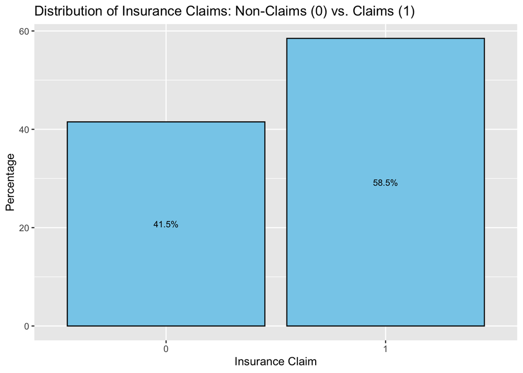

```r
percentage_data <- table(insurance.data$insuranceclaim) / nrow(insurance.data) * 100

# Create a data frame for plotting
plot_data <- data.frame(insuranceclaim = as.factor(names(percentage_data)),
                        percentage = as.numeric(percentage_data))

# Plotting
ggplot(plot_data, aes(x = insuranceclaim, y = percentage)) +
  geom_bar(stat = "identity", fill = "skyblue", color = "black") +
  geom_text(aes(label = sprintf("%.1f%%", percentage)),
            position = position_stack(vjust = 0.5),   # Adjust vjust for vertical position
            color = "black", size = 3) +
  labs(title = "Distribution of Insurance Claims: Non-Claims (0) vs. Claims (1)",
       x = "Insurance Claim",
       y = "Percentage")
```

Following code is to split the data into the trian and test split’s in the proportion of 80% and 20%

```r
# Binomial Logit Model - 80-20 split

set.seed(123457)
train.prop <- 0.80
strats <- insurance.data$insuranceclaim
rr <- split(1:length(strats), strats)
idx <- sort(as.numeric(unlist(sapply(rr,
        function(x) sample(x, length(x)*train.prop)))))
insurance.data.train <- insurance.data[idx, ]
insurance.data.test <- insurance.data[-idx, ]
```

Following are the distributions of the claims and no claims in the train and test data frames with similar distributions.

```r
#check for equal proportions of number of claims

table(insurance.data.train$insuranceclaim)/nrow(insurance.data.train)
```

```
##
##         0         1
## 0.4153414 0.5846586
```

```r
table(insurance.data.test$insuranceclaim)/nrow(insurance.data.test)
```

```
##
##         0         1
## 0.4141791 0.5858209
```

Basis on the response variable with 0’s and 1’s which is a binomial we can apply binary logit model

A **binary random variable** $Y$ can assume only one of two possible values, a value of $1$ (Yes) or a value of $0$ (No).

A binary random variable $Y$ has a Bernoulli($\pi$) distribution with

$$P(Y=1)=\pi = 1-P(Y=0),$$
{#eq-bernoulli}

and probability mass function (p.m.f.)

$$p(y; \pi) = \pi^y (1-\pi)^{1-y},~y = 0 \mbox{ or } 1; 0 \le \pi \le 1.$$
{#eq-pmfBern}

A useful transformation of $\pi$ is the logit (or, log-odds) transformation:

$$\text{logit}(\pi) = \log \left(\frac{\pi}{1-\pi}\right)$$
{#eq-logitpi}

Let $\eta = \text{logit}(\pi)$. After some algebra, we see that we can uniquely write $\pi$ as a function of $\eta$, i.e., the inverse transformation is

$$\pi = \frac{\exp(\eta)}{1+\exp(\eta)}$$
{#eq-invlogit}

### Logit Model

The binary logit (or, logistic regression) model is a generalized linear model (GLIM) for explaining binary responses $Y_i$. Our goal is to model the binary responses as functions of $p$ independent variables denoted by $X_{i,j},~j=1,\ldots,p$ for each $i$.

The *random component* of the GLIM is

$$Y_i | \pi_i \sim \mbox{Bernoulli}(\pi_i).$$
{#eq-logitglim1}

The *systematic component* is

$$\eta_i = \beta_0 + \sum_{j=1}^p \beta_j X_{i,j} = \mathbf{x}_i'
\boldsymbol{\beta}.$$
{#eq-binarysys}

with $\boldsymbol{\beta} = (\beta_0, \beta_1, \ldots,\beta_p)'$, and $\mathbf{x}_i = (1, X_{i,1},\ldots, X_{i,p})'$.

The *logit link function* relates the $i$th mean response $\pi_i$ to the systematic component $\eta_i$:

$$\mbox{logit}(\pi_i | \mathbf{x}_i) =
\log\left(\frac{\pi_i}{1-\pi_i}\right) = \eta_i.$$
{#eq-logitglim2}

Since the mean response $\pi_i$ must lie in the interval $(0,1)$, whereas $\eta_i$ is real-valued, we need a function such as the logit function to link the two in a correct way.

By inverting the logit link function (see @eq-invlogit), we can write the binary logit model as

$$\pi_i = P(Y_i =1 | \mathbf{x}_i) = \frac{\exp(\beta_0 +
\sum_{j=1}^p \beta_j X_{i,j})}{
1+ \exp(\beta_0 + \sum_{j=1}^p \beta_j X_{i,j})}.$$
{#eq-logitglim3}

1. Full Binary logit model was fitted on the data where the response variable is insuranceclaims and the remaining variables such as sex, children, bmi, smokers, age, region and charges.

Following are the null and alternative hypothesis.

**Null Hypothesis ($H_0$):**
$$H_0: \beta_j = 0$$

The null hypothesis asserts that there is no association between the independent variable $X_j$ and the log-odds of the dependent variable being in the “success” category.

**Alternative Hypothesis ($H_1$):**
$$H_1: \beta_j \neq 0$$

The alternative hypothesis suggests that the independent variable $X_j$ does have a significant association with the log-odds of the event.

```r
#full binary logit model
full.logit <- glm(insuranceclaim ~ . ,data = insurance.data.train,
                  family = binomial(link = "logit"))
summary(full.logit)
```

```
##
## Call:
## glm(formula = insuranceclaim ~ ., family = binomial(link = "logit"),
##     data = insurance.data.train)
##
## Coefficients:
##               Estimate Std. Error z value Pr(>|z|)
## (Intercept) -7.733e+00  6.882e-01 -11.237  < 2e-16 ***
## age          3.137e-02  8.573e-03   3.659 0.000253 ***
## sex1         6.626e-02  1.845e-01   0.359 0.719451
## bmi          2.790e-01  2.178e-02  12.807  < 2e-16 ***
## children1   -2.183e+00  2.413e-01  -9.046  < 2e-16 ***
## children2   -3.487e+00  2.951e-01 -11.815  < 2e-16 ***
## children3   -4.880e+00  4.021e-01 -12.137  < 2e-16 ***
## children4   -5.051e+00  7.472e-01  -6.760 1.38e-11 ***
## children5   -3.880e+00  8.897e-01  -4.361 1.29e-05 ***
## smoker1      4.112e+00  4.710e-01   8.730  < 2e-16 ***
## region1     -3.719e-01  2.617e-01  -1.421 0.155270
## region2     -3.596e-01  2.668e-01  -1.348 0.177625
## region3     -3.058e-01  2.628e-01  -1.164 0.244625
## charges      1.022e-05  1.749e-05   0.584 0.559263
## ---
## Signif. codes:  0 '***' 0.001 '**' 0.01 '*' 0.05 '.' 0.1 ' ' 1
##
## (Dispersion parameter for binomial family taken to be 1)
##
##     Null deviance: 1451.15  on 1068  degrees of freedom
## Residual deviance:  751.29  on 1055  degrees of freedom
## AIC: 779.29
##
## Number of Fisher Scoring iterations: 6
```

# Logistic Regression Results Interpretation

## Coefficients

### Age

For each one-unit increase in age, the log-odds of making an insurance claim increase by 0.0314 (p < 0.001).

### Sex

The coefficient for ‘sex1’ is 0.06626 with a p-value of 0.719. It is not statistically significant, suggesting that gender may not be a significant predictor of insurance claims.

### BMI

For each one-unit increase in BMI, the log-odds of making an insurance claim increase by 0.279 (p < 0.001).

### Children

The coefficients for ‘children1’ through ‘children5’ represent the effect of having 1 to 5 children compared to having no children. As the number of children increases, the log-odds of making an insurance claim decrease significantly.

### Smoker

Smokers (smoker1) have higher log-odds of making an insurance claim compared to non-smokers (4.112, p < 0.001).

### Charges

The coefficient for ‘charges’ is not statistically significant (p = 0.559), suggesting that charges may not be a significant predictor.

## Model Fit

- The model significantly improves the fit compared to the null model (p < 2e-16).
- AIC (Akaike Information Criterion) is 779.29, a measure of model performance.

## Dispersion Parameter

- The dispersion parameter is 1, indicating that the binomial distribution is appropriate for the data.

## Deviance

- The null deviance (1451.15) represents the deviance when considering only the intercept.
- The residual deviance (751.29) is the deviance after fitting the model with predictors. A lower deviance indicates a better fit.

## Conclusion

- Age, BMI, number of children, and smoking status appear to be significant predictors of insurance claims.
- Charges and region may not be statistically significant predictors in this model.

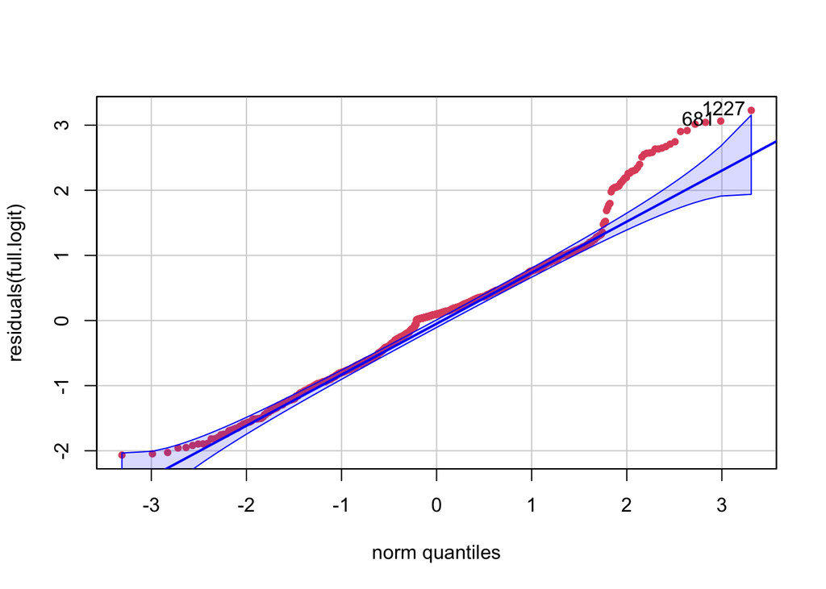

```
## 1227  681
##  982  554
```

```r
car::qqPlot(residuals(full.logit), main = NA, pch = 19, col = 2, cex = 0.7)
```

```r
shapiro.test(residuals(full.logit))
```

```
##
##  Shapiro-Wilk normality test
##
## data:  residuals(full.logit)
## W = 0.97353, p-value = 4.624e-13
```

From the above residual plot we can observe most of the data points were normal except few data points however according to the shapiro wilk statistical test we can confirm that the data is not normal.

Following null binary model was fitted with no predictors with the repsonse variable

```r
#null binary logit model
null.logit <- glm(insuranceclaim ~ 1 ,data = insurance.data.train,
                  family = binomial(link = "logit"))
summary(null.logit)
```

```
##
## Call:
## glm(formula = insuranceclaim ~ 1, family = binomial(link = "logit"),
##     data = insurance.data.train)
##
## Coefficients:
##             Estimate Std. Error z value Pr(>|z|)
## (Intercept)  0.34193    0.06207   5.509 3.61e-08 ***
## ---
## Signif. codes:  0 '***' 0.001 '**' 0.01 '*' 0.05 '.' 0.1 ' ' 1
##
## (Dispersion parameter for binomial family taken to be 1)
##
##     Null deviance: 1451.2  on 1068  degrees of freedom
## Residual deviance: 1451.2  on 1068  degrees of freedom
## AIC: 1453.2
##
## Number of Fisher Scoring iterations: 4
```

The model with only the intercept doesn’t provide much information about the relationship between predictors and the response variable. It serves as a baseline against which more complex models can be compared.

The AIC is relatively high, suggesting that models with additional predictors might provide a better fit to the data.

Since there are no predictor variables, the model is essentially stating that the log-odds of making an insurance claim when there are no predictors is 0.34193.

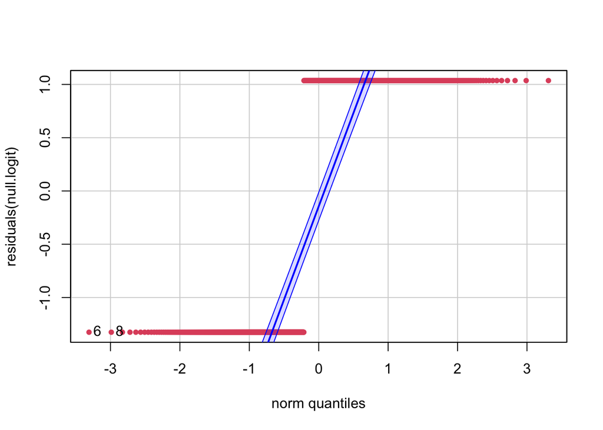

```
## 6 8
## 3 5
```

```r
car::qqPlot(residuals(null.logit), main = NA, pch = 19, col = 2, cex = 0.7)
```

```r
shapiro.test(residuals(null.logit))
```

```
##
##  Shapiro-Wilk normality test
##
## data:  residuals(null.logit)
## W = 0.62609, p-value < 2.2e-16
```

```r
both.logit <- step(null.logit, list(lower = formula(null.logit),
                                    upper = formula(full.logit)),
                   direction = "both", trace = 0, data = insurance.data.train)

formula(both.logit)
```

```
## insuranceclaim ~ children + bmi + smoker + age
```

```r
summary(both.logit)
```

```
##
## Call:
## glm(formula = insuranceclaim ~ children + bmi + smoker + age,
##     family = binomial(link = "logit"), data = insurance.data.train)
##
## Coefficients:
##              Estimate Std. Error z value Pr(>|z|)
## (Intercept) -7.916898   0.665702 -11.893  < 2e-16 ***
## children1   -2.184042   0.240776  -9.071  < 2e-16 ***
## children2   -3.478784   0.294150 -11.827  < 2e-16 ***
## children3   -4.868815   0.399380 -12.191  < 2e-16 ***
## children4   -5.008194   0.747916  -6.696 2.14e-11 ***
## children5   -3.886841   0.892521  -4.355 1.33e-05 ***
## bmi          0.276118   0.021134  13.065  < 2e-16 ***
## smoker1      4.281770   0.374253  11.441  < 2e-16 ***
## age          0.034454   0.007052   4.885 1.03e-06 ***
## ---
## Signif. codes:  0 '***' 0.001 '**' 0.01 '*' 0.05 '.' 0.1 ' ' 1
##
## (Dispersion parameter for binomial family taken to be 1)
##
##     Null deviance: 1451.15  on 1068  degrees of freedom
## Residual deviance:  754.42  on 1060  degrees of freedom
## AIC: 772.42
##
## Number of Fisher Scoring iterations: 6
```

The model suggests that the number of children, BMI, smoking status, and age are significant predictors of insurance claims.

Smokers are associated with a significant increase in the likelihood of making an insurance claim.

Older individuals (higher age) are associated with a slight increase in the likelihood of making an insurance claim.

The model provides a significantly better fit than the null model, as evidenced by the lower residual deviance and AIC.

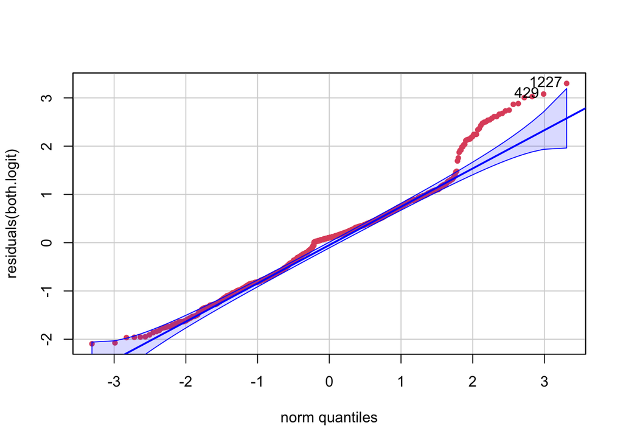

```
## 1227  429
##  982  347
```

```r
car::qqPlot(residuals(both.logit), main = NA, pch = 19, col = 2, cex = 0.7)
```

```r
shapiro.test(residuals(both.logit))
```

```
##
##  Shapiro-Wilk normality test
##
## data:  residuals(both.logit)
## W = 0.9734, p-value = 4.245e-13
```

According to the above residual plot the data was not normal

There are outliers after fitting the model, let’s the model by eliminating the residuals which are having the variation greater than 3 times of standard deviation. Following is the code implementation

```r
extpts <- which(abs(residuals(both.logit)) > 3*sd(residuals(both.logit)))
nrow(insurance.data.train)
```

```
## [1] 1069
```

```r
length(extpts)
```

```
## [1] 15
```

```r
data.train.2 <- insurance.data.train[-extpts,]
full.logit <- glm(insuranceclaim ~ . ,data = data.train.2,
                  family = binomial(link = "logit"))
both.logit.extpts <- step(full.logit,
                   direction="both",trace=0, data = data.train.2)
formula(both.logit.extpts)
```

```
## insuranceclaim ~ age + bmi + children + smoker
```

```r
summary(both.logit.extpts)
```

```
##
## Call:
## glm(formula = insuranceclaim ~ age + bmi + children + smoker,
##     family = binomial(link = "logit"), data = data.train.2)
##
## Coefficients:
##               Estimate Std. Error z value Pr(>|z|)
## (Intercept) -10.666757   0.852947 -12.506  < 2e-16 ***
## age           0.038961   0.007922   4.918 8.74e-07 ***
## bmi           0.371495   0.027749  13.388  < 2e-16 ***
## children1    -2.696091   0.278386  -9.685  < 2e-16 ***
## children2    -4.272616   0.353996 -12.070  < 2e-16 ***
## children3    -7.124781   0.575888 -12.372  < 2e-16 ***
## children4    -7.670886   1.080693  -7.098 1.26e-12 ***
## children5    -4.539262   1.005026  -4.517 6.29e-06 ***
## smoker1       5.928896   0.513490  11.546  < 2e-16 ***
## ---
## Signif. codes:  0 '***' 0.001 '**' 0.01 '*' 0.05 '.' 0.1 ' ' 1
##
## (Dispersion parameter for binomial family taken to be 1)
##
##     Null deviance: 1434.90  on 1053  degrees of freedom
## Residual deviance:  610.43  on 1045  degrees of freedom
## AIC: 628.43
##
## Number of Fisher Scoring iterations: 7
```

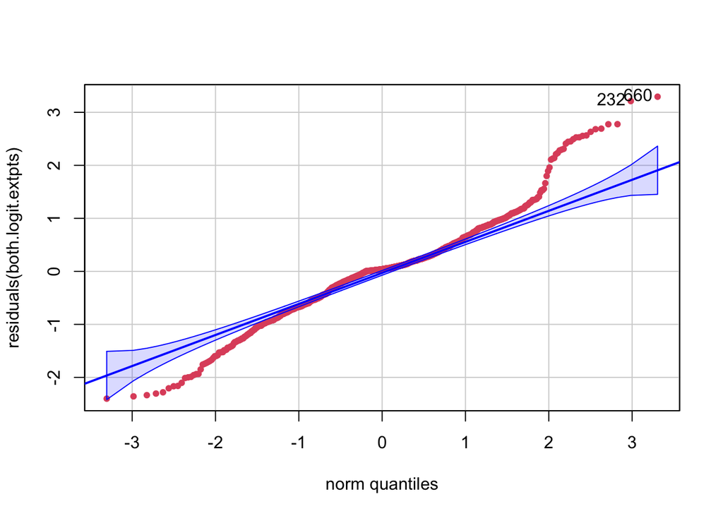

```
## 660 232
## 528 182
```

```r
car::qqPlot(residuals(both.logit.extpts), main = NA, pch = 19, col = 2, cex = 0.7)
```

```r
shapiro.test(residuals(both.logit.extpts))
```

```
##
##  Shapiro-Wilk normality test
##
## data:  residuals(both.logit.extpts)
## W = 0.96129, p-value = 4.199e-16
```

From the residual plot we see the data points are deviated and are not normal.

The Akaike Information Criterion (AIC) is an information criterion used for model selection. For a model with $p$ estimated parameters, it is defined as

$$\text{AIC} = -2 \ell(\hat{\boldsymbol{\beta}};\mathbf{y}) + 2p.$$
{#eq-AIC}

While we wish to select a model with largest maximized log-likelihood, AIC penalizes us for using a model with an unnecessarily large $p$, the penalty term being $2p$.

Let’s compare the AIC values

```r
#Akaike Information Criterion
AIC(both.logit)
```

```
## [1] 772.4223
```

```r
AIC(full.logit)
```

```
## [1] 634.5677
```

```r
AIC(null.logit)
```

```
## [1] 1453.154
```

From the above values we can observe full.logit model aic values as less which compared to others

Another useful information based model selection criterion is called the Bayesian Information Criterion (BIC), which uses a different penalty $p\log(n)$:
$$\text{BIC} = -2 \ell(\hat{\boldsymbol{\beta}};\mathbf{y}) + p \log(n)$$
{#eq-BIC}

Again, a model with smaller BIC is better which is full.logit model in comparison to the both logit model.

```r
#Baysian Information Criteria
BIC(both.logit)
```

```
## [1] 817.1926
```

```r
BIC(full.logit)
```

```
## [1] 704.0126
```

```r
BIC(null.logit)
```

```
## [1] 1458.129
```

Let’s predict the values of the test data set by the help of predict function by passing the model as well as the dataset along side the type as response where it will automatically takes care of the logit conversions.

## Test Data Accuracy

Predictions with the help of the both.logit as well as the full.logit model.

```r
pred.both.test <- predict(both.logit, newdata = insurance.data.test, type="response")
pred.full.test <- predict(full.logit, newdata = insurance.data.test, type="response")
```

```r
(table.both <- table(pred.both.test > 0.5, insurance.data.test$insuranceclaim))
```

```
##
##           0   1
##   FALSE  90  18
##   TRUE   21 139
```

```r
(table.full <- table(pred.full.test > 0.5, insurance.data.test$insuranceclaim))
```

```
##
##           0   1
##   FALSE  95  16
##   TRUE   16 141
```

```r
(accuracy.both <- round((sum(diag(table.both))/sum(table.both))*100,2))
```

```
## [1] 85.45
```

```r
(accuracy.full <- round((sum(diag(table.full))/sum(table.full))*100,2))
```

```
## [1] 88.06
```

We can observe that the accuracy of the test data by the full model is more which compared to the both model.

**ROC curve.** Another useful metric is area under the **receiver operating characteristics** (ROC) curve, which used to evaluate the prediction accuracy in binary and multi-class classification.

It quantifies the trade-off between the sensitivity or true positive rate (TPR) and specificity or false positive rate (FPR) of a prediction.

**Sensitivity**, or true positive (TP) is the probability that a binary response is predicted as a 1 (or, yes), given that it is an event (or, yes).

**Specificity**, or true negative (TN) is the probability that a binary response is predicted as a 0 (or, no), given that it is a non-event (or, no).

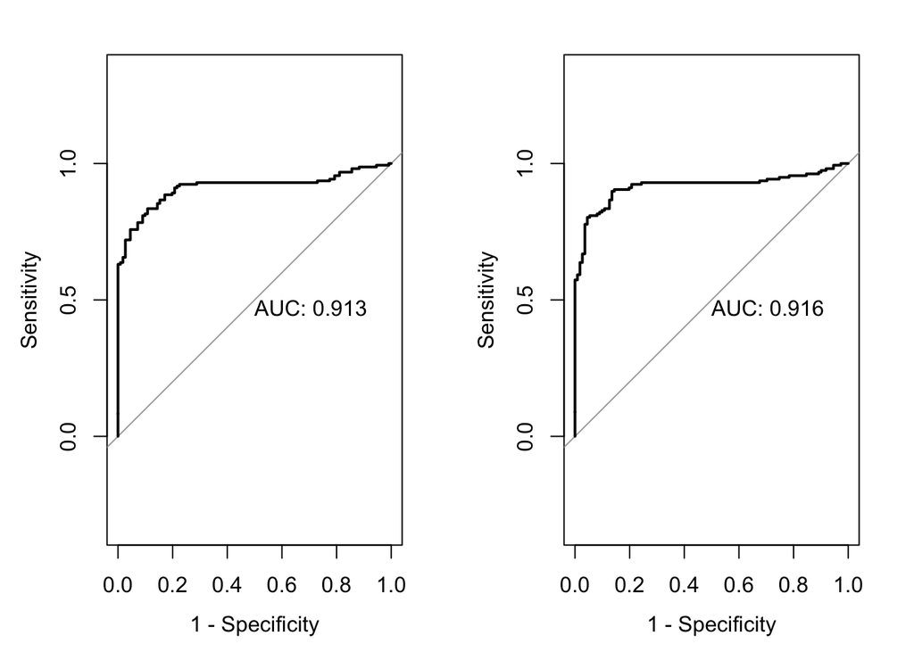

```r
par(mfrow = c(1,2))
roc.both <- roc(insurance.data.test$insuranceclaim ~ pred.both.test, plot = TRUE,
                legacy.axes = TRUE, print.auc = TRUE)
roc.both <- roc(insurance.data.test$insuranceclaim ~ pred.full.test, plot = TRUE,
                legacy.axes = TRUE, print.auc = TRUE)
```

## Train Data Accuracy

Following are the predictions, accuracy and roc curves on the train data.

```r
pred.both <- predict(both.logit, newdata = insurance.data.train, type="response")
pred.full <- predict(full.logit, newdata = insurance.data.train, type="response")
```

```r
(table.both <- table(pred.both > 0.5, insurance.data.train$insuranceclaim))
```

```
##
##           0   1
##   FALSE 371  62
##   TRUE   73 563
```

```r
(table.full <- table(pred.full > 0.5, insurance.data.train$insuranceclaim))
```

```
##
##           0   1
##   FALSE 384  63
##   TRUE   60 562
```

```r
(accuracy.both <- round((sum(diag(table.both))/sum(table.both))*100,2))
```

```
## [1] 87.37
```

```r
(accuracy.full <- round((sum(diag(table.full))/sum(table.full))*100,2))
```

```
## [1] 88.49
```

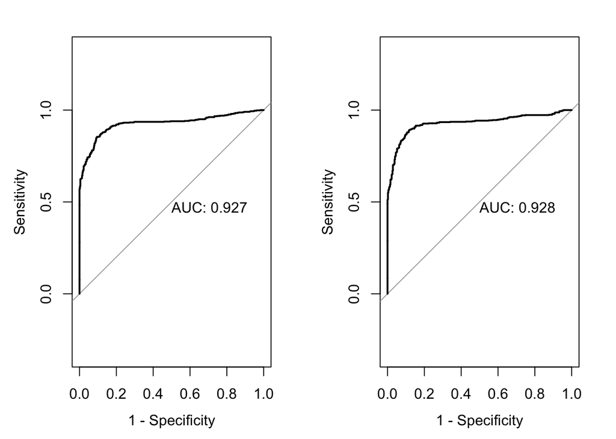

```r
par(mfrow = c(1,2))
roc.both <- roc(insurance.data.train$insuranceclaim ~ pred.both, plot = TRUE,
                legacy.axes = TRUE, print.auc = TRUE)
roc.both <- roc(insurance.data.train$insuranceclaim ~ pred.full, plot = TRUE,
                legacy.axes = TRUE, print.auc = TRUE)
```

We can observe that the train and test data accuracy were similar for the full model where as there is a slight difference between them in the both model. AUC curve looks similar for both the both as well as the full model.

##backward

Model was fitted based on the backward direction and the aic value is 628 which is less when compared to the both model.

```r
both.logit.backward <- step(full.logit,
                   direction="backward",trace=0, data = insurance.data.train)
formula(both.logit.backward)
```

```
## insuranceclaim ~ age + bmi + children + smoker
```

```r
summary(both.logit.backward)
```

```
##
## Call:
## glm(formula = insuranceclaim ~ age + bmi + children + smoker,
##     family = binomial(link = "logit"), data = data.train.2)
##
## Coefficients:
##               Estimate Std. Error z value Pr(>|z|)
## (Intercept) -10.666757   0.852947 -12.506  < 2e-16 ***
## age           0.038961   0.007922   4.918 8.74e-07 ***
## bmi           0.371495   0.027749  13.388  < 2e-16 ***
## children1    -2.696091   0.278386  -9.685  < 2e-16 ***
## children2    -4.272616   0.353996 -12.070  < 2e-16 ***
## children3    -7.124781   0.575888 -12.372  < 2e-16 ***
## children4    -7.670886   1.080693  -7.098 1.26e-12 ***
## children5    -4.539262   1.005026  -4.517 6.29e-06 ***
## smoker1       5.928896   0.513490  11.546  < 2e-16 ***
## ---
## Signif. codes:  0 '***' 0.001 '**' 0.01 '*' 0.05 '.' 0.1 ' ' 1
##
## (Dispersion parameter for binomial family taken to be 1)
##
##     Null deviance: 1434.90  on 1053  degrees of freedom
## Residual deviance:  610.43  on 1045  degrees of freedom
## AIC: 628.43
##
## Number of Fisher Scoring iterations: 7
```

Features such as age, bmi, children and smoker are the ones which were identified by the backward model as more relevant in predicting the response variable.

However, residual plot does not loks good as it indicates the data points are not normal.

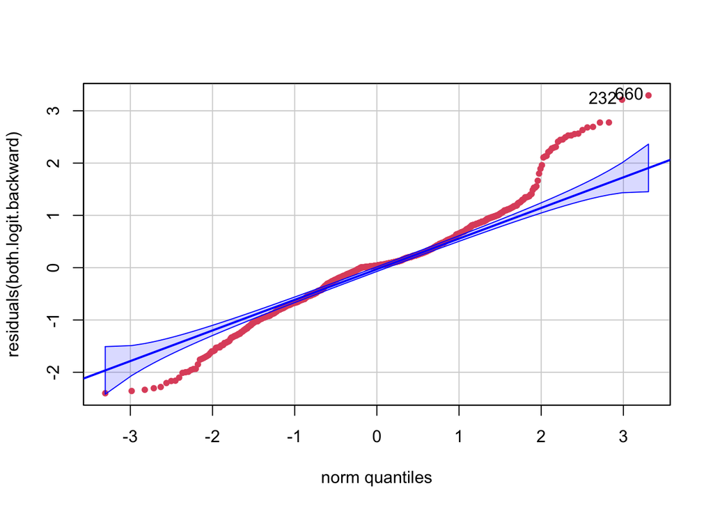

```
## 660 232
## 528 182
```

```r
car::qqPlot(residuals(both.logit.backward), main = NA, pch = 19, col = 2, cex = 0.7)
```

```r
shapiro.test(residuals(both.logit.backward))
```

```
##
##  Shapiro-Wilk normality test
##
## data:  residuals(both.logit.backward)
## W = 0.96129, p-value = 4.199e-16
```

##forward

Following is the code for the forward elimination method and it’s AIC value is 634 which is slightly greater than the backward model.

```r
both.logit.forward <- step(full.logit,
                   direction="forward",trace=0, data = insurance.data.train)
formula(both.logit.forward)
```

```
## insuranceclaim ~ age + sex + bmi + children + smoker + region +
##     charges
```

```r
summary(both.logit.forward)
```

```
##
## Call:
## glm(formula = insuranceclaim ~ age + sex + bmi + children + smoker +
##     region + charges, family = binomial(link = "logit"), data = data.train.2)
##
## Coefficients:
##               Estimate Std. Error z value Pr(>|z|)
## (Intercept) -1.052e+01  8.758e-01 -12.009  < 2e-16 ***
## age          3.617e-02  9.719e-03   3.722 0.000198 ***
## sex1         7.141e-02  2.071e-01   0.345 0.730266
## bmi          3.777e-01  2.861e-02  13.199  < 2e-16 ***
## children1   -2.702e+00  2.799e-01  -9.653  < 2e-16 ***
## children2   -4.288e+00  3.559e-01 -12.049  < 2e-16 ***
## children3   -7.162e+00  5.819e-01 -12.308  < 2e-16 ***
## children4   -7.697e+00  1.087e+00  -7.078 1.46e-12 ***
## children5   -4.529e+00  1.005e+00  -4.508 6.55e-06 ***
## smoker1      5.805e+00  6.032e-01   9.624  < 2e-16 ***
## region1     -4.717e-01  2.935e-01  -1.607 0.108100
## region2     -4.886e-01  2.982e-01  -1.639 0.101253
## region3     -3.348e-01  2.931e-01  -1.142 0.253393
## charges      8.773e-06  1.982e-05   0.443 0.658053
## ---
## Signif. codes:  0 '***' 0.001 '**' 0.01 '*' 0.05 '.' 0.1 ' ' 1
##
## (Dispersion parameter for binomial family taken to be 1)
##
##     Null deviance: 1434.90  on 1053  degrees of freedom
## Residual deviance:  606.57  on 1040  degrees of freedom
## AIC: 634.57
##
## Number of Fisher Scoring iterations: 7
```

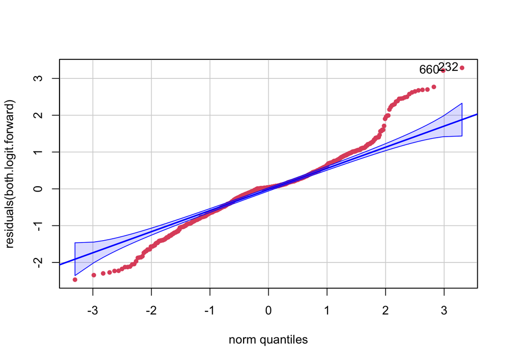

```
## 232 660
## 182 528
```

```r
car::qqPlot(residuals(both.logit.forward), main = NA, pch = 19, col = 2, cex = 0.7)
```

```r
shapiro.test(residuals(both.logit.forward))
```

```
##
##  Shapiro-Wilk normality test
##
## data:  residuals(both.logit.forward)
## W = 0.96088, p-value = 3.394e-16
```

However, residual plot does not loks good as it indicates the data points are not normal.

Following are the predictions, accuracy of the test data for both forward and backward elimination models.

```r
pred.both.forward <- predict(both.logit.forward, newdata = insurance.data.test, type="response")
pred.both.backward <- predict(both.logit.backward, newdata = insurance.data.test, type="response")
```

```r
(table.both.forward <- table(pred.both.forward > 0.5, insurance.data.test$insuranceclaim))
```

```
##
##           0   1
##   FALSE  95  16
##   TRUE   16 141
```

```r
(table.full.backward <- table(pred.both.backward > 0.5, insurance.data.test$insuranceclaim))
```

```
##
##           0   1
##   FALSE  92  18
##   TRUE   19 139
```

```r
(accuracy.both.forward <- round((sum(diag(table.both.forward))/sum(table.both.forward))*100,2))
```

```
## [1] 88.06
```

```r
(accuracy.full.backward <- round((sum(diag(table.full.backward))/sum(table.full.backward))*100,2))
```

```
## [1] 86.19
```

We can observe the ac curacies of both the forward and backward elimination methods are similar to that of both elimination methods.

Testing Strategy 2 - **K-Fold Validation**

K-fold cross-validation is a resampling technique commonly used in machine learning to assess the performance and generalization ability of a predictive model. The basic idea is to partition the dataset into k subsets (folds), train the model on k-1 folds, and evaluate it on the remaining fold. This process is repeated k times, with each of the k folds used exactly once as the validation data.

Following code implements the **k-fold validation** with 10 folds on the **full model** and the average accuracy obtained is 87%(approx).

```r
# Binomial Full Logit Model - K fold validaton

# Set the number of folds (K)
num_folds <- 10

# Create an index vector for splitting
set.seed(123)  # for reproducibility
indices <- createFolds(insurance.data$insuranceclaim, k = num_folds, list = TRUE)

# Initialize a variable to store cross-validation results
cv_results <- data.frame(Accuracies = double(num_folds))

# Perform K-Fold Cross-Validation
for (i in 1:num_folds) {
  # Split the data into training and testing sets
  train_data <- insurance.data[-indices[[i]], ]
  test_data <- insurance.data[indices[[i]], ]

  # Fit your model on the training data
  model <- glm(insuranceclaim ~ . ,data = train_data,
                  family = binomial(link = "logit"))

  # Make predictions on the test data
  predictions <- predict(model, newdata = test_data,  type="response")

  (table.full <- table(predictions > 0.5, test_data$insuranceclaim))

  acc <- round((sum(diag(table.full))/sum(table.full))*100,2)

  # Store the RMSE in the results dataframe
  cv_results$Accuracies[i] <- acc
}

# Display cross-validation results
print(cv_results)
```

```
##    Accuracies
## 1       86.47
## 2       87.31
## 3       87.41
## 4       84.96
## 5       87.22
## 6       85.07
## 7       85.82
## 8       84.33
## 9       93.23
## 10      86.57
```

```r
cv_results$Accuracies <- as.numeric(cv_results$Accuracies)
mean_accuracy <- mean(cv_results$Accuracies, na.rm = TRUE)
mean_accuracy
```

```
## [1] 86.839
```

```r
# Binomial Logit Model - K fold validation
```

Following code implements the **k-fold validation** with 10 folds on the **both model** and the average accuracy obtained is 88%.

```r
# Binomial Both Logit Model - K fold validaton

# Set the number of folds (K)
num_folds <- 10

# Create an index vector for splitting
set.seed(123)  # for reproducibility
indices <- createFolds(insurance.data$insuranceclaim, k = num_folds, list = TRUE)

# Initialize a variable to store cross-validation results
cv_results <- data.frame(Accuracies = double(num_folds))

# Perform K-Fold Cross-Validation
for (i in 1:num_folds) {
  # Split the data into training and testing sets
  train_data <- insurance.data[-indices[[i]], ]
  test_data <- insurance.data[indices[[i]], ]

  # Fit your model on the training data
  model <- step(full.logit,
                   direction="both",trace=0, data = train_data)

  # Make predictions on the test data
  predictions <- predict(model, newdata = test_data,  type="response")

  (table.full <- table(predictions > 0.5, test_data$insuranceclaim))

  acc <- round((sum(diag(table.full))/sum(table.full))*100,2)

  # Store the RMSE in the results dataframe
  cv_results$Accuracies[i] <- acc
}

# Display cross-validation results
print(cv_results)
```

```
##    Accuracies
## 1       86.47
## 2       88.06
## 3       88.15
## 4       85.71
## 5       88.72
## 6       86.57
## 7       88.81
## 8       85.82
## 9       93.23
## 10      88.81
```

```r
cv_results$Accuracies <- as.numeric(cv_results$Accuracies)
mean_accuracy <- mean(cv_results$Accuracies, na.rm = TRUE)
mean_accuracy
```

```
## [1] 88.035
```

```r
# Binomial Logit Model - K fold validation
```

The probit link function is an alternative link function.

Starting with the standard normal c.d.f $\phi(z)$ which lies in the interval $[0, 1]$, the probit (or inverse normal c.d.f.) link assumes that

$$\phi^{-1}(\pi_i) = \eta_i$$
{#eq-probit1}

so that

$$\pi_i = \Phi(\eta_i)$$
{#eq-probit2}

where $\eta_i$ is given by @eq-binarysys as

$$\eta_i = \beta_0 + \sum_{j=1}^p \beta_j X_{i,j} = \mathbf{x}_i'
\boldsymbol{\beta}.$$
**Null Hypothesis ($H_0$):**
$$H_0: \beta_j = 0$$

The null hypothesis asserts that there is no association between the independent variable $X_j$ and the probability of the dependent variable being in the “success” category.

**Alternative Hypothesis ($H_1$):**
$$H_1: \beta_j \neq 0$$

The alternative hypothesis suggests that the independent variable $X_j$ does have a significant association with the probability of the event.

```r
# Probit Full Model

full.probit <- glm(insuranceclaim ~ . ,data = insurance.data.train ,
                   family = binomial(link = "probit"))
summary(full.probit)
```

```
##
## Call:
## glm(formula = insuranceclaim ~ ., family = binomial(link = "probit"),
##     data = insurance.data.train)
##
## Coefficients:
##               Estimate Std. Error z value Pr(>|z|)
## (Intercept) -4.012e+00  3.591e-01 -11.173  < 2e-16 ***
## age          1.821e-02  4.694e-03   3.879 0.000105 ***
## sex1         3.719e-02  1.028e-01   0.362 0.717537
## bmi          1.458e-01  1.108e-02  13.158  < 2e-16 ***
## children1   -1.232e+00  1.325e-01  -9.295  < 2e-16 ***
## children2   -1.923e+00  1.561e-01 -12.317  < 2e-16 ***
## children3   -2.571e+00  2.026e-01 -12.692  < 2e-16 ***
## children4   -2.623e+00  3.826e-01  -6.857 7.02e-12 ***
## children5   -2.107e+00  4.526e-01  -4.654 3.25e-06 ***
## smoker1      2.162e+00  2.518e-01   8.585  < 2e-16 ***
## region1     -2.164e-01  1.460e-01  -1.482 0.138392
## region2     -1.982e-01  1.496e-01  -1.325 0.185238
## region3     -1.820e-01  1.475e-01  -1.234 0.217249
## charges      6.872e-06  9.576e-06   0.718 0.472970
## ---
## Signif. codes:  0 '***' 0.001 '**' 0.01 '*' 0.05 '.' 0.1 ' ' 1
##
## (Dispersion parameter for binomial family taken to be 1)
##
##     Null deviance: 1451.15  on 1068  degrees of freedom
## Residual deviance:  765.01  on 1055  degrees of freedom
## AIC: 793.01
##
## Number of Fisher Scoring iterations: 7
```

Age (age): A one-unit increase in age is associated with an increase in the log-odds of making an insurance claim by 0.01821. This effect is statistically significant.

Sex (sex1): The coefficient is not statistically significant at the 0.05 significance level, suggesting that gender may not be a significant predictor of insurance claims.

BMI (bmi): A one-unit increase in BMI is associated with an increase in the log-odds of making an insurance claim by 0.1458. This effect is statistically significant.

Children (children1, children2, children3, children4, children5): The number of children has a significant negative impact on the log-odds of making an insurance claim.

Smoker (smoker1): Being a smoker is associated with an increase in the log-odds of making an insurance claim by 2.162. This effect is highly significant.

Region (region1, region2, region3): The coefficients for regions are not statistically significant, suggesting that region may not be a significant predictor of insurance claims.

Charges (charges): The coefficient is not statistically significant at the 0.05 significance level, indicating that charges may not be a significant predictor of insurance claims.

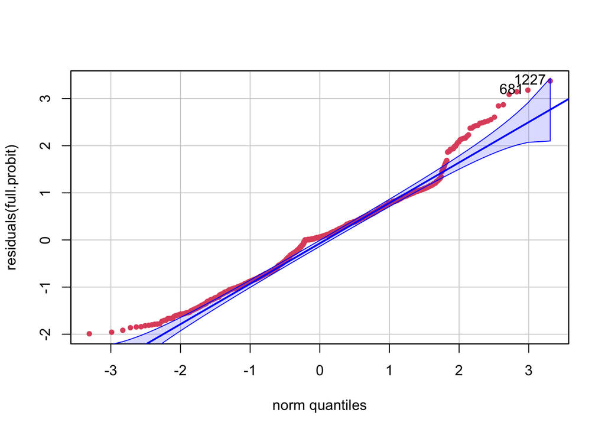

```
## 1227  681
##  982  554
```

```r
car::qqPlot(residuals(full.probit), main = NA, pch = 19, col = 2, cex = 0.7)
```

```r
shapiro.test(residuals(full.probit))
```

```
##
##  Shapiro-Wilk normality test
##
## data:  residuals(full.probit)
## W = 0.97872, p-value = 2.062e-11
```

From the resiudal plot we can ibserve that the data points are not normal which we can also proven statistically by shapiro-wilk test.

```r
#train data accuracy
pred.both <- predict(full.probit, newdata = insurance.data.train, type="response")
(table.both <- table(pred.both > 0.5, insurance.data.train$insuranceclaim))
```

```
##
##           0   1
##   FALSE 364  56
##   TRUE   80 569
```

```r
(accuracy.both.forward <- round((sum(diag(table.both.forward))/sum(table.both.forward))*100,2))
```

```
## [1] 88.06
```

```r
#test data accuracy
pred.both <- predict(full.probit, newdata = insurance.data.test, type="response")
(table.both <- table(pred.both > 0.5, insurance.data.test$insuranceclaim))
```

```
##
##           0   1
##   FALSE  87  17
##   TRUE   24 140
```

```r
(accuracy.both.forward <- round((sum(diag(table.both.forward))/sum(table.both.forward))*100,2))
```

```
## [1] 88.06
```

Following is the code to fit the probit model on the reduced predictors such as age, bmi, children, smoker

```r
# Probit Model

full.predictors.probit <- glm(insuranceclaim ~ age + bmi + children + smoker ,data = insurance.data.train ,
                   family = binomial(link = "probit"))
summary(full.predictors.probit)
```

```
##
## Call:
## glm(formula = insuranceclaim ~ age + bmi + children + smoker,
##     family = binomial(link = "probit"), data = insurance.data.train)
##
## Coefficients:
##              Estimate Std. Error z value Pr(>|z|)
## (Intercept) -4.124238   0.344506 -11.971  < 2e-16 ***
## age          0.020223   0.003899   5.187 2.14e-07 ***
## bmi          0.144275   0.010687  13.500  < 2e-16 ***
## children1   -1.232168   0.132227  -9.319  < 2e-16 ***
## children2   -1.912556   0.155338 -12.312  < 2e-16 ***
## children3   -2.568484   0.201282 -12.761  < 2e-16 ***
## children4   -2.583550   0.380364  -6.792 1.10e-11 ***
## children5   -2.092116   0.452774  -4.621 3.83e-06 ***
## smoker1      2.279723   0.191072  11.931  < 2e-16 ***
## ---
## Signif. codes:  0 '***' 0.001 '**' 0.01 '*' 0.05 '.' 0.1 ' ' 1
##
## (Dispersion parameter for binomial family taken to be 1)
##
##     Null deviance: 1451.15  on 1068  degrees of freedom
## Residual deviance:  768.43  on 1060  degrees of freedom
## AIC: 786.43
##
## Number of Fisher Scoring iterations: 7
```

The probit link function is an alternative link function.

Starting with the standard normal c.d.f $\phi(z)$ which lies in the interval $[0, 1]$, the probit (or inverse normal c.d.f.) link assumes that

$$\phi^{-1}(\pi_i) = \eta_i$$
{#eq-probit1}

so that

$$\pi_i = \Phi(\eta_i)$$
{#eq-probit2}

where $\eta_i$ is given by @eq-binarysys as

$$\eta_i = \beta_0 + \sum_{j=1}^p \beta_j X_{i,j} = \mathbf{x}_i'
\boldsymbol{\beta}.$$

The Fisher scoring (FS) algorithm is again used to obtain MLE’s of the regression coefficients.

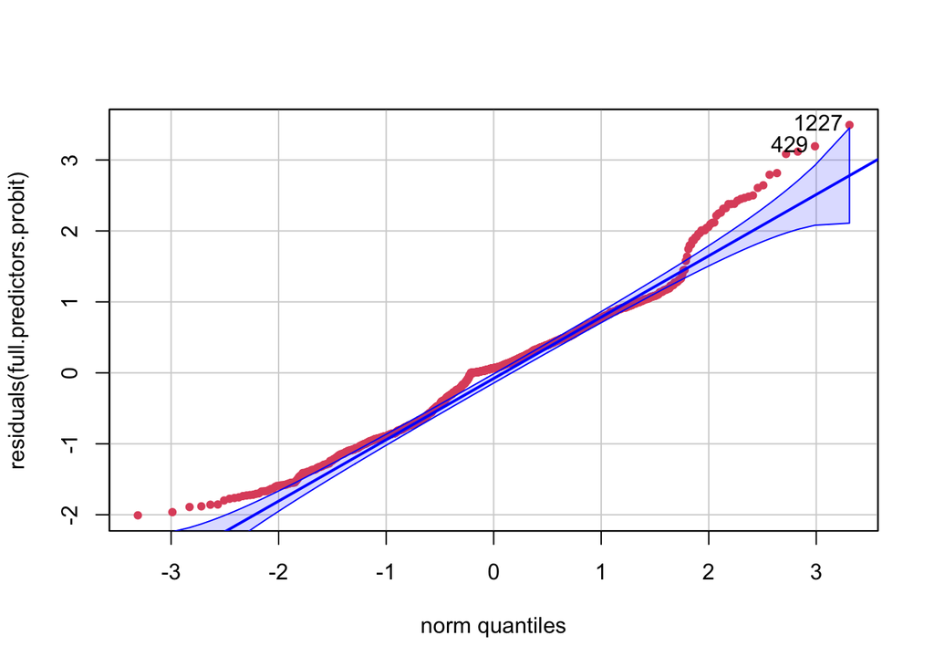

```
## 1227  429
##  982  347
```

```r
car::qqPlot(residuals(full.predictors.probit), main = NA, pch = 19, col = 2, cex = 0.7)
```

```r
shapiro.test(residuals(full.predictors.probit))
```

```
##
##  Shapiro-Wilk normality test
##
## data:  residuals(full.predictors.probit)
## W = 0.97837, p-value = 1.574e-11
```

Above plot illustrates that the data points are not normal as there are deviations from the normal line.

```r
pred.both.train.probit <- predict(full.predictors.probit, newdata = insurance.data.train, type="response")
(table.both <- table(pred.both.train.probit > 0.5, insurance.data.train$insuranceclaim))
```

```
##
##           0   1
##   FALSE 366  57
##   TRUE   78 568
```

```r
(accuracy.both.forward <- round((sum(diag(table.both.forward))/sum(table.both.forward))*100,2))
```

```
## [1] 88.06
```

```r
pred.both.test.probit <- predict(full.predictors.probit, newdata = insurance.data.test, type="response")
(table.both <- table(pred.both.test.probit > 0.5, insurance.data.test$insuranceclaim))
```

```
##
##           0   1
##   FALSE  88  15
##   TRUE   23 142
```

```r
(accuracy.both.forward <- round((sum(diag(table.both.forward))/sum(table.both.forward))*100,2))
```

```
## [1] 88.06
```

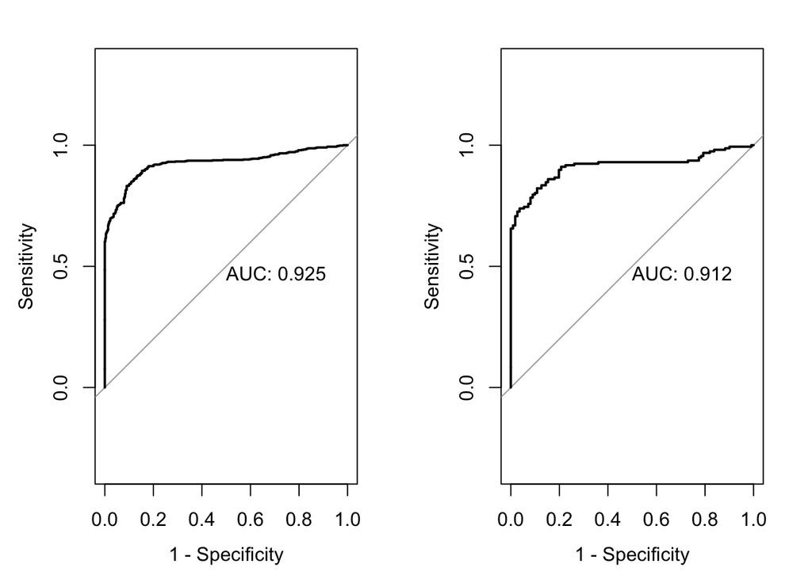

```r
par(mfrow = c(1,2))
roc.both <- roc(insurance.data.train$insuranceclaim ~ pred.both.train.probit, plot = TRUE,
                legacy.axes = TRUE, print.auc = TRUE)
roc.both <- roc(insurance.data.test$insuranceclaim ~ pred.both.test.probit, plot = TRUE,
                legacy.axes = TRUE, print.auc = TRUE)
```

```r
# Binomial Full Probit Model - K fold validaton


# Set the number of folds (K)
num_folds <- 10

# Create an index vector for splitting
set.seed(123)  # for reproducibility
indices <- createFolds(insurance.data$insuranceclaim, k = num_folds, list = TRUE)

# Initialize a variable to store cross-validation results
cv_results <- data.frame(Accuracies = double(num_folds))

# Perform K-Fold Cross-Validation
for (i in 1:num_folds) {
  # Split the data into training and testing sets
  train_data <- insurance.data[-indices[[i]], ]
  test_data <- insurance.data[indices[[i]], ]

  # Fit your model on the training data
  model <- glm(insuranceclaim ~ . ,data = train_data,
                  family = binomial(link = "probit"))

  # Make predictions on the test data
  predictions <- predict(model, newdata = test_data,  type="response")

  (table.full <- table(predictions > 0.5, test_data$insuranceclaim))

  acc <- round((sum(diag(table.full))/sum(table.full))*100,2)

  # Store the RMSE in the results dataframe
  cv_results$Accuracies[i] <- acc
}

# Display cross-validation results
print(cv_results)
```

```
##    Accuracies
## 1       86.47
## 2       86.57
## 3       86.67
## 4       84.21
## 5       87.22
## 6       84.33
## 7       85.07
## 8       84.33
## 9       92.48
## 10      85.82
```

```r
cv_results$Accuracies <- as.numeric(cv_results$Accuracies)
mean_accuracy <- mean(cv_results$Accuracies, na.rm = TRUE)
mean_accuracy
```

```
## [1] 86.317
```

```r
# Binomial Logit Model - K fold validation
```

# 3. Classification and Regression Trees

We define two impurity measures, Gini index and entropy, for classifying a response with $J$ categories.

The **Gini index** is defined by

$$\mbox{Gini index} = 1 - \sum_{j=1}^J p^2_j,$$
{#eq-gini-index}

where $p_j = P(Y \in \mbox{class} j),~j=1,\ldots,J$. Gini index lies in $[0, 1]$. The value $0$ denotes a pure classification where all the cases belong to a single class, while $1$ indicates a random distribution of cases across the $J$ classes. A Gini index of $0.5$ shows an equal distribution of cases over some classes.

**Entropy** is an alternate impurity measure which also lies in $[0,1]$:

$$\mbox{Entropy} = \sum_{j=1}^J-p_j \log_2 (p_j).$$
{#eq-entropy}

The *rpart* package uses the Gini index as the impurity index and minimizes a cost

$$\text{Cost}_{CP}(\mbox{Tree}) = \mbox{Error(Tree)} + Cp \
\mathcal{N}(\mbox{Tree}),$$

where, Error(Tree) is the fraction of misclassified cases and $\mathcal{N}(\mbox{Tree})$ is the number of leaf nodes in the tree.

```r
# Classification and Regression Trees

insurance.data.dup <- read.csv("~/Documents/GitHub/GitHub/Insurance-Claim-Prediction/data/insurance.csv")
insurance.data <- insurance.data.dup
```

```r
set.seed(12345)
train.prop <- 0.80
strats <- insurance.data$insuranceclaim
rr <- split(1:length(strats), strats)
idx <- sort(as.numeric(unlist(sapply(rr,
        function(x) sample(x, length(x)*train.prop)))))
insurance.data.train <- insurance.data[idx, ]
insurance.data.test <- insurance.data[-idx, ]
table(insurance.data.train$insuranceclaim)/nrow(insurance.data.train)
```

```
##
##         0         1
## 0.4149533 0.5850467
```

```r
fit.allp <- rpart(insuranceclaim ~., method = "class", data = insurance.data.train,
                  control = rpart.control(minsplit = 1, cp = 0.001))
summary(fit.allp)
```

```
## Call:
## rpart(formula = insuranceclaim ~ ., data = insurance.data.train,
##     method = "class", control = rpart.control(minsplit = 1, cp = 0.001))
##   n= 1070
##
##             CP nsplit   rel error     xerror       xstd
## 1  0.315315315      0 1.000000000 1.00000000 0.03629976
## 2  0.128378378      1 0.684684685 0.71846847 0.03370082
## 3  0.051801802      3 0.427927928 0.43693694 0.02838429
## 4  0.043918919      4 0.376126126 0.42792793 0.02815421
## 5  0.033783784      6 0.288288288 0.32432432 0.02514270
## 6  0.027027027      7 0.254504505 0.29954955 0.02430641
## 7  0.020270270      8 0.227477477 0.25675676 0.02273037
## 8  0.018018018     10 0.186936937 0.23648649 0.02191712
## 9  0.016891892     11 0.168918919 0.19594595 0.02013546
## 10 0.015765766     13 0.135135135 0.19594595 0.02013546
## 11 0.013513514     14 0.119369369 0.17117117 0.01892453
## 12 0.012762763     15 0.105855856 0.16891892 0.01880907
## 13 0.009009009     18 0.067567568 0.10585586 0.01509774
## 14 0.006756757     19 0.058558559 0.10360360 0.01494356
## 15 0.005630631     22 0.038288288 0.08333333 0.01346096
## 16 0.004504505     24 0.027027027 0.08333333 0.01346096
## 17 0.002252252     27 0.013513514 0.05630631 0.01112893
## 18 0.001126126     30 0.006756757 0.05405405 0.01090929
## 19 0.001000000     36 0.000000000 0.05180180 0.01068470
##
## Variable importance
##      bmi children  charges   smoker      age   region
##       31       26       20       12       10        1
##
## Node number 1: 1070 observations,    complexity param=0.3153153
##   predicted class=1  expected loss=0.4149533  P(node) =1
##     class counts:   444   626
##    probabilities: 0.415 0.585
##   left son=2 (244 obs) right son=3 (826 obs)
##   Primary splits:
##       bmi      < 25.9825  to the left,  improve=87.44814, (0 missing)
##       children < 0.5      to the right, improve=82.55445, (0 missing)
##       smoker   < 0.5      to the left,  improve=57.01775, (0 missing)
##       charges  < 33047.5  to the left,  improve=45.12917, (0 missing)
```

[output cut: 668 more lines]

```
##
## Node number 823: 21 observations
##   predicted class=1  expected loss=0  P(node) =0.01962617
##     class counts:     0    21
##    probabilities: 0.000 1.000
##
## Node number 828: 1 observations
##   predicted class=0  expected loss=0  P(node) =0.0009345794
##     class counts:     1     0
##    probabilities: 1.000 0.000
##
## Node number 829: 4 observations
##   predicted class=1  expected loss=0  P(node) =0.003738318
##     class counts:     0     4
##    probabilities: 0.000 1.000
```

The *root node error* is the percent of incorrectly classified cases at the first (root) splitting node. That is,

```r
(rootnode_err <- sum(insurance.data.train$insuranceclaim==1)/nrow(insurance.data.train))
```

```
## [1] 0.5850467
```

```r
printcp(fit.allp)
```

```
##
## Classification tree:
## rpart(formula = insuranceclaim ~ ., data = insurance.data.train,
##     method = "class", control = rpart.control(minsplit = 1, cp = 0.001))
##
## Variables actually used in tree construction:
## [1] age      bmi      charges  children smoker
##
## Root node error: 444/1070 = 0.41495
##
## n= 1070
##
##           CP nsplit rel error   xerror     xstd
## 1  0.3153153      0 1.0000000 1.000000 0.036300
## 2  0.1283784      1 0.6846847 0.718468 0.033701
## 3  0.0518018      3 0.4279279 0.436937 0.028384
## 4  0.0439189      4 0.3761261 0.427928 0.028154
## 5  0.0337838      6 0.2882883 0.324324 0.025143
## 6  0.0270270      7 0.2545045 0.299550 0.024306
## 7  0.0202703      8 0.2274775 0.256757 0.022730
## 8  0.0180180     10 0.1869369 0.236486 0.021917
## 9  0.0168919     11 0.1689189 0.195946 0.020135
## 10 0.0157658     13 0.1351351 0.195946 0.020135
## 11 0.0135135     14 0.1193694 0.171171 0.018925
## 12 0.0127628     15 0.1058559 0.168919 0.018809
## 13 0.0090090     18 0.0675676 0.105856 0.015098
## 14 0.0067568     19 0.0585586 0.103604 0.014944
## 15 0.0056306     22 0.0382883 0.083333 0.013461
## 16 0.0045045     24 0.0270270 0.083333 0.013461
## 17 0.0022523     27 0.0135135 0.056306 0.011129
## 18 0.0011261     30 0.0067568 0.054054 0.010909
## 19 0.0010000     36 0.0000000 0.051802 0.010685
```

```r
max(fit.allp$cptable[,"nsplit"])
```

```
## [1] 36
```

```r
min(fit.allp$cptable[,"nsplit"])
```

```
## [1] 0
```

```r
plotcp(fit.allp)
```

[output not shown]

```r
(cp= fit.allp$cptable[which.min(fit.allp$cptable[, "xerror"]), "CP"])
```

```
## [1] 0.001
```

```r
(xerr = fit.allp$cptable[which.min(fit.allp$cptable[, "xerror"]), "xerror"])
```

```
## [1] 0.0518018
```

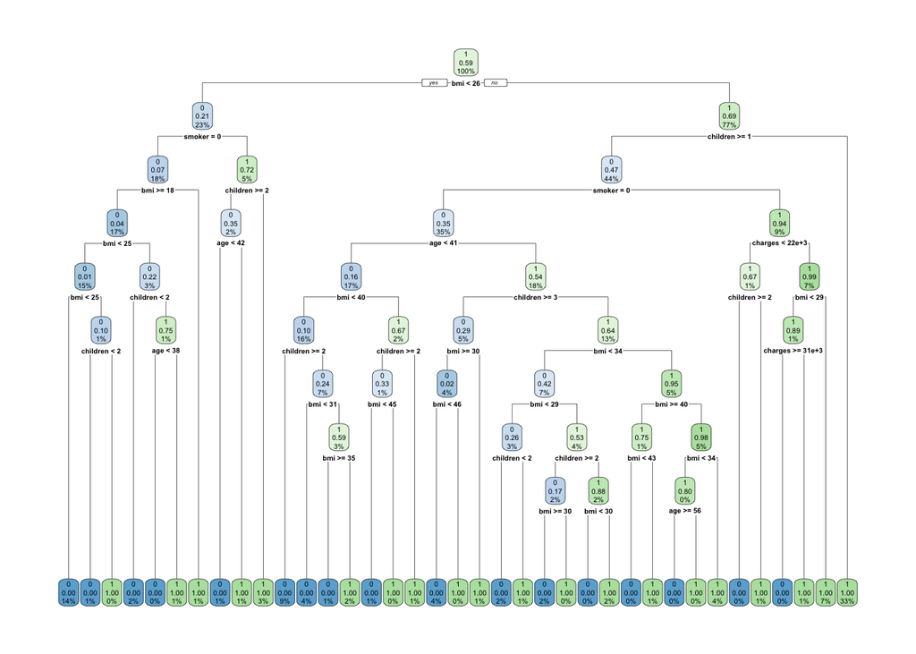

```r
rpart.plot(fit.allp, extra = "auto")
```

```r
test_df <- data.frame(actual = insurance.data.test$insuranceclaim, pred = NA)
test_df$pred <- predict(fit.allp, newdata = insurance.data.test, type = "class")
(conf_matrix_base <- table(test_df$pred, test_df$actual)) #confusion matrix
```

```
##
##       0   1
##   0 108   3
##   1   3 154
```

```r
sensitivity(conf_matrix_base)
```

```
## [1] 0.972973
```

```r
specificity(conf_matrix_base)
```

```
## [1] 0.9808917
```

```r
(mis.rate <- conf_matrix_base[1, 2] +
   conf_matrix_base[2, 1])/sum(conf_matrix_base)
```

```
## [1] 0.02238806
```

```r
#Hyper Parameter Tuning

fit.allf <- rpart(insuranceclaim ~., method = "class", data = insurance.data.train,
                  control = rpart.control(cp = 0.0001))

plotcp(fit.allp)
```

[output not shown]

```r
test_df <- data.frame(actual = insurance.data.test$insuranceclaim, pred = NA)
test_df$pred <- predict(fit.allp, newdata = insurance.data.test, type = "class")
(conf_matrix_base <- table(test_df$pred, test_df$actual)) #confusion matrix
```

```
##
##       0   1
##   0 108   3
##   1   3 154
```

```r
sensitivity(conf_matrix_base)
```

```
## [1] 0.972973
```

```r
specificity(conf_matrix_base)
```

```
## [1] 0.9808917
```

```r
(mis.rate <- conf_matrix_base[1, 2] +
   conf_matrix_base[2, 1])/sum(conf_matrix_base)
```

```
## [1] 0.02238806
```

```r
fit.allf <- rpart(insuranceclaim ~., method = "class", data = insurance.data.train,
                  control = rpart.control(cp = 0.1))

plotcp(fit.allp)
```

[output not shown]

```r
test_df <- data.frame(actual = insurance.data.test$insuranceclaim, pred = NA)
test_df$pred <- predict(fit.allp, newdata = insurance.data.test, type = "class")
(conf_matrix_base <- table(test_df$pred, test_df$actual)) #confusion matrix
```

```
##
##       0   1
##   0 108   3
##   1   3 154
```

```r
sensitivity(conf_matrix_base)
```

```
## [1] 0.972973
```

```r
specificity(conf_matrix_base)
```

```
## [1] 0.9808917
```

```r
(mis.rate <- conf_matrix_base[1, 2] +
   conf_matrix_base[2, 1])/sum(conf_matrix_base)
```

```
## [1] 0.02238806
```

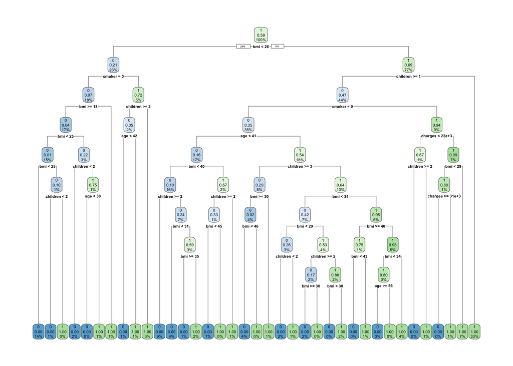

```r
#Prune the tree
pfit.allp <- prune(fit.allp, cp =
    fit.allp$cptable[which.min(fit.allp$cptable[, "xerror"]), "CP"])
rpart.plot(pfit.allp, extra = "auto")
```

```r
summary(pfit.allp)
```

```
## Call:
## rpart(formula = insuranceclaim ~ ., data = insurance.data.train,
##     method = "class", control = rpart.control(minsplit = 1, cp = 0.001))
##   n= 1070
##
##             CP nsplit   rel error     xerror       xstd
## 1  0.315315315      0 1.000000000 1.00000000 0.03629976
## 2  0.128378378      1 0.684684685 0.71846847 0.03370082
## 3  0.051801802      3 0.427927928 0.43693694 0.02838429
## 4  0.043918919      4 0.376126126 0.42792793 0.02815421
## 5  0.033783784      6 0.288288288 0.32432432 0.02514270
## 6  0.027027027      7 0.254504505 0.29954955 0.02430641
## 7  0.020270270      8 0.227477477 0.25675676 0.02273037
## 8  0.018018018     10 0.186936937 0.23648649 0.02191712
## 9  0.016891892     11 0.168918919 0.19594595 0.02013546
## 10 0.015765766     13 0.135135135 0.19594595 0.02013546
## 11 0.013513514     14 0.119369369 0.17117117 0.01892453
## 12 0.012762763     15 0.105855856 0.16891892 0.01880907
## 13 0.009009009     18 0.067567568 0.10585586 0.01509774
## 14 0.006756757     19 0.058558559 0.10360360 0.01494356
## 15 0.005630631     22 0.038288288 0.08333333 0.01346096
## 16 0.004504505     24 0.027027027 0.08333333 0.01346096
## 17 0.002252252     27 0.013513514 0.05630631 0.01112893
## 18 0.001126126     30 0.006756757 0.05405405 0.01090929
## 19 0.001000000     36 0.000000000 0.05180180 0.01068470
##
## Variable importance
##      bmi children  charges   smoker      age   region
##       31       26       20       12       10        1
##
## Node number 1: 1070 observations,    complexity param=0.3153153
##   predicted class=1  expected loss=0.4149533  P(node) =1
##     class counts:   444   626
##    probabilities: 0.415 0.585
##   left son=2 (244 obs) right son=3 (826 obs)
##   Primary splits:
##       bmi      < 25.9825  to the left,  improve=87.44814, (0 missing)
##       children < 0.5      to the right, improve=82.55445, (0 missing)
##       smoker   < 0.5      to the left,  improve=57.01775, (0 missing)
##       charges  < 33047.5  to the left,  improve=45.12917, (0 missing)
```

[output cut: 668 more lines]

```
##
## Node number 823: 21 observations
##   predicted class=1  expected loss=0  P(node) =0.01962617
##     class counts:     0    21
##    probabilities: 0.000 1.000
##
## Node number 828: 1 observations
##   predicted class=0  expected loss=0  P(node) =0.0009345794
##     class counts:     1     0
##    probabilities: 1.000 0.000
##
## Node number 829: 4 observations
##   predicted class=1  expected loss=0  P(node) =0.003738318
##     class counts:     0     4
##    probabilities: 0.000 1.000
```

```r
#Measures of Predictive Performance
rootnode_err <- sum(insurance.data.train$insuranceclaim==1)/nrow(insurance.data.train)
prelerr = pfit.allp$cptable[which.min(pfit.allp$cptable[, "rel error"]), "rel error"]
(presub.err_rate <- rootnode_err*prelerr)
```

```
## [1] 0
```

```r
rootnode_err <- sum(insurance.data.train$insuranceclaim==1)/nrow(insurance.data.train)
pxerr = pfit.allp$cptable[which.min(pfit.allp$cptable[, "xerror"]), "xerror"]
(pcv.err_rate <- rootnode_err*pxerr)
```

```
## [1] 0.03030647
```

```r
test_df <- data.frame(actual = insurance.data.test$insuranceclaim, pred = NA)
test_df$pred <- predict(pfit.allp, newdata = insurance.data.test, type = "class")
(conf_matrix_pruned_tree <-
    table(test_df$pred, test_df$actual)) #confusion matrix
```

```
##
##       0   1
##   0 108   3
##   1   3 154
```

```r
sensitivity(conf_matrix_pruned_tree)
```

```
## [1] 0.972973
```

```r
specificity(conf_matrix_pruned_tree)
```

```
## [1] 0.9808917
```

```r
# Missclassification error rate:
(conf_matrix_pruned_tree[1, 2] +
    conf_matrix_pruned_tree[2, 1])/sum(conf_matrix_pruned_tree)
```

```
## [1] 0.02238806
```

```r
# Random Forest

fit.rf.ranger <- ranger(insuranceclaim ~ ., data = insurance.data.train,
                   importance = 'impurity', mtry = 3)
print(fit.rf.ranger)
```

```
## Ranger result
##
## Call:
##  ranger(insuranceclaim ~ ., data = insurance.data.train, importance = "impurity",      mtry = 3)
##
## Type:                             Regression
## Number of trees:                  500
## Sample size:                      1070
## Number of independent variables:  7
## Mtry:                             3
## Target node size:                 5
## Variable importance mode:         impurity
## Splitrule:                        variance
## OOB prediction error (MSE):       0.03148481
## R squared (OOB):                  0.8704297
```

```r
(v1 <- vi(fit.rf.ranger))
```

```
## # A tibble: 7 × 2
##   Variable Importance
##   <chr>         <dbl>
## 1 bmi           93.1
## 2 children      73.5
## 3 charges       34.5
## 4 smoker        24.9
## 5 age           20.9
## 6 region         3.69
## 7 sex            1.37
```

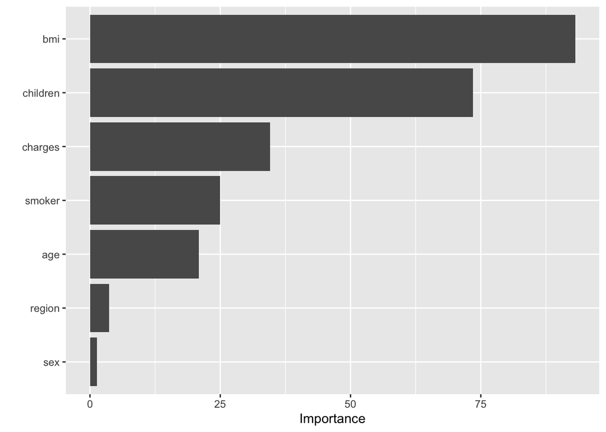

```r
vip(v1)
```

```r
# Assuming your predictions are stored in the variable 'pred'
pred <- predict(fit.rf.ranger, data = insurance.data.test)

# Create a data frame with actual and predicted values
test_df <- data.frame(actual = insurance.data.test$insuranceclaim,
                      pred = ifelse(pred$predictions > 0.5, 1, 0))

# Create a confusion matrix
conf_matrix_rf <- table(test_df$pred, test_df$actual)

# Display the confusion matrix
print(conf_matrix_rf)
```

```
##
##       0   1
##   0 106   2
##   1   5 155
```

```r
# Sensitivity
sensitivity(conf_matrix_rf)
```

```
## [1] 0.954955
```

```r
# Specificity
specificity(conf_matrix_rf)
```

```
## [1] 0.9872611
```

```r
# Missclassification error rate:
(conf_matrix_rf[1,2] + conf_matrix_rf[2,1])/sum(conf_matrix_rf)
```

```
## [1] 0.0261194
```

#Dropping the columns which are hvaing the less vip value

```r
# dropped the sex column
fit.rf.ranger <- ranger(insuranceclaim ~ bmi+children+age+smoker+charges+region, data = insurance.data.train,
                   importance = 'impurity', mtry = 3)

print(fit.rf.ranger)
```

```
## Ranger result
##
## Call:
##  ranger(insuranceclaim ~ bmi + children + age + smoker + charges +      region, data = insurance.data.train, importance = "impurity",      mtry = 3)
##
## Type:                             Regression
## Number of trees:                  500
## Sample size:                      1070
## Number of independent variables:  6
## Mtry:                             3
## Target node size:                 5
## Variable importance mode:         impurity
## Splitrule:                        variance
## OOB prediction error (MSE):       0.02560531
## R squared (OOB):                  0.8946258
```

```r
(v1 <- vi(fit.rf.ranger))
```

```
## # A tibble: 6 × 2
##   Variable Importance
##   <chr>         <dbl>
## 1 bmi           96.7
## 2 children      75.2
## 3 charges       33.0
## 4 smoker        26.1
## 5 age           20.1
## 6 region         2.98
```

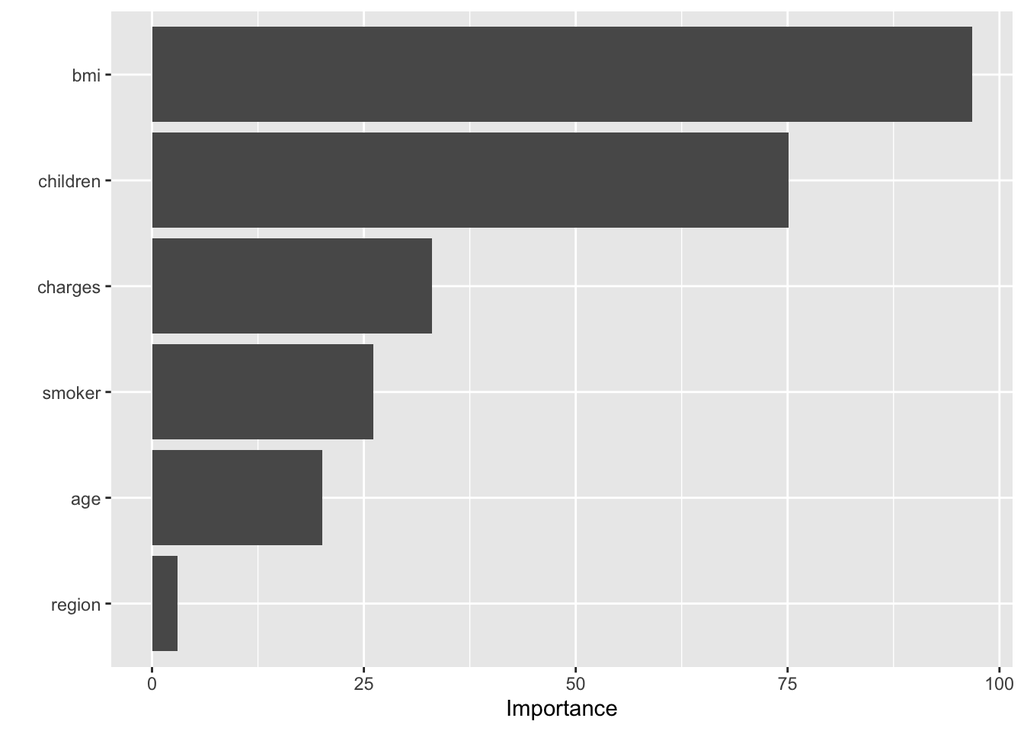

```r
vip(v1)
```

```r
pred <- predict(fit.rf.ranger, data = insurance.data.test)
# Create a data frame with actual and predicted values
test_df <- data.frame(actual = insurance.data.test$insuranceclaim,
                      pred = ifelse(pred$predictions > 0.5, 1, 0))
# Create a confusion matrix
conf_matrix_rf <- table(test_df$pred, test_df$actual)
# Display the confusion matrix
print(conf_matrix_rf)
```

```
##
##       0   1
##   0 109   1
##   1   2 156
```

```r
# Sensitivity
sensitivity(conf_matrix_rf)
```

```
## [1] 0.981982
```

```r
# Specificity
specificity(conf_matrix_rf)
```

```
## [1] 0.9936306
```

```r
# Missclassification error rate:
(conf_matrix_rf[1,2] + conf_matrix_rf[2,1])/sum(conf_matrix_rf)
```

```
## [1] 0.01119403
```

```r
# dropped the sex and region column
fit.rf.ranger <- ranger(insuranceclaim ~ bmi+children+age+smoker+charges, data = insurance.data.train,
                   importance = 'impurity', mtry = 3)

print(fit.rf.ranger)
```

```
## Ranger result
##
## Call:
##  ranger(insuranceclaim ~ bmi + children + age + smoker + charges,      data = insurance.data.train, importance = "impurity", mtry = 3)
##
## Type:                             Regression
## Number of trees:                  500
## Sample size:                      1070
## Number of independent variables:  5
## Mtry:                             3
## Target node size:                 5
## Variable importance mode:         impurity
## Splitrule:                        variance
## OOB prediction error (MSE):       0.02029162
## R squared (OOB):                  0.9164934
```

```r
(v1 <- vi(fit.rf.ranger))
```

```
## # A tibble: 5 × 2
##   Variable Importance
##   <chr>         <dbl>
## 1 bmi            99.6
## 2 children       78.1
## 3 charges        30.3
## 4 smoker         28.1
## 5 age            19.6
```

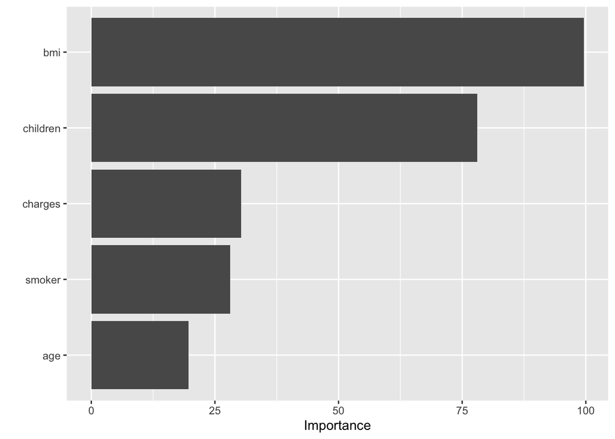

```r
vip(v1)
```

```r
pred <- predict(fit.rf.ranger, data = insurance.data.test)
# Create a data frame with actual and predicted values
test_df <- data.frame(actual = insurance.data.test$insuranceclaim,
                      pred = ifelse(pred$predictions > 0.5, 1, 0))
# Create a confusion matrix
conf_matrix_rf <- table(test_df$pred, test_df$actual)
# Display the confusion matrix
print(conf_matrix_rf)
```

```
##
##       0   1
##   0 109   1
##   1   2 156
```

```r
# Sensitivity
sensitivity(conf_matrix_rf)
```

```
## [1] 0.981982
```

```r
# Specificity
specificity(conf_matrix_rf)
```

```
## [1] 0.9936306
```

```r
# Missclassification error rate:
(conf_matrix_rf[1,2] + conf_matrix_rf[2,1])/sum(conf_matrix_rf)
```

```
## [1] 0.01119403
```

```r
# dropped the sex, age and region column
fit.rf.ranger <- ranger(insuranceclaim ~ bmi+children+smoker+charges, data = insurance.data.train,
                   importance = 'impurity', mtry = 3)

print(fit.rf.ranger)
```

```
## Ranger result
##
## Call:
##  ranger(insuranceclaim ~ bmi + children + smoker + charges, data = insurance.data.train,      importance = "impurity", mtry = 3)
##
## Type:                             Regression
## Number of trees:                  500
## Sample size:                      1070
## Number of independent variables:  4
## Mtry:                             3
## Target node size:                 5
## Variable importance mode:         impurity
## Splitrule:                        variance
## OOB prediction error (MSE):       0.02523464
## R squared (OOB):                  0.8961513
```

```r
(v1 <- vi(fit.rf.ranger))
```

```
## # A tibble: 4 × 2
##   Variable Importance
##   <chr>         <dbl>
## 1 bmi           101.
## 2 children       80.2
## 3 charges        42.2
## 4 smoker         31.8
```

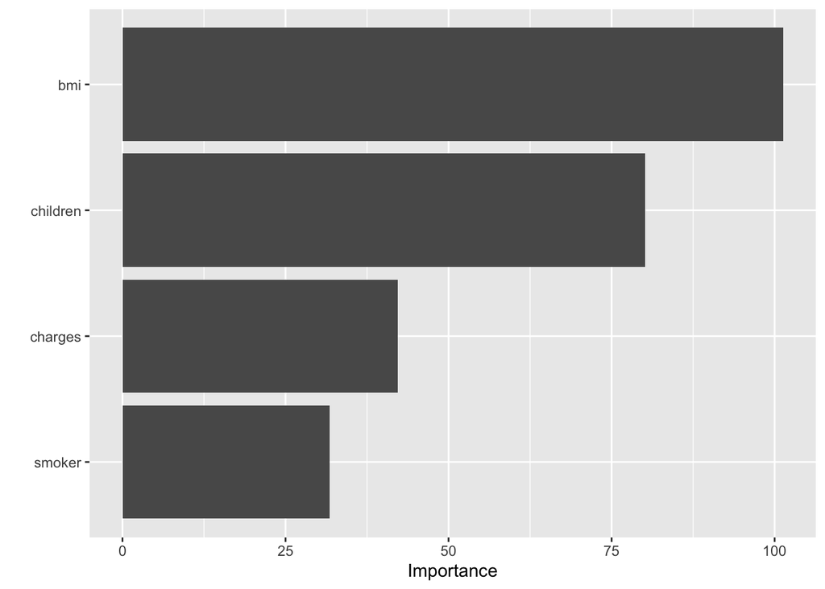

```r
vip(v1)
```

```r
pred <- predict(fit.rf.ranger, data = insurance.data.test)
# Create a data frame with actual and predicted values
test_df <- data.frame(actual = insurance.data.test$insuranceclaim,
                      pred = ifelse(pred$predictions > 0.5, 1, 0))
# Create a confusion matrix
conf_matrix_rf <- table(test_df$pred, test_df$actual)
# Display the confusion matrix
print(conf_matrix_rf)
```

```
##
##       0   1
##   0 109   3
##   1   2 154
```

```r
# Sensitivity
sensitivity(conf_matrix_rf)
```

```
## [1] 0.981982
```

```r
# Specificity
specificity(conf_matrix_rf)
```

```
## [1] 0.9808917
```

```r
# Missclassification error rate:
(conf_matrix_rf[1,2] + conf_matrix_rf[2,1])/sum(conf_matrix_rf)
```

```
## [1] 0.01865672
```

# 5. Gradient Boosting

```r
# Transform the predictor matrix using dummy (or indicator or one-hot) encoding
matrix_predictors.train <-
  as.matrix(sparse.model.matrix(insuranceclaim ~., data = insurance.data.train))[, -1]
matrix_predictors.test <-
  as.matrix(sparse.model.matrix(insuranceclaim ~., data = insurance.data.test))[, -1]
```

```r
# Train dataset
pred.train.gbm <- data.matrix(matrix_predictors.train) # predictors only
#convert factor to numeric
insurance.data.train.gbm <- as.numeric(as.character(insurance.data.train$insuranceclaim))
```

```r
dtrain <- xgb.DMatrix(data = pred.train.gbm, label = insurance.data.train.gbm)
# Test dataset
pred.test.gbm <- data.matrix(matrix_predictors.test) # predictors only
 #convert factor to numeric
insurance.data.test.gbm <- as.numeric(as.character(insurance.data.test$insuranceclaim))
```

```r
dtest <- xgb.DMatrix(data = pred.test.gbm, label = insurance.data.test.gbm)

watchlist <- list(train = dtrain, test = dtest)
param <- list(max_depth = 2, eta = 1, nthread = 2,
              objective = "binary:logistic", eval_metric = "auc")

model.xgb <- xgb.train(param, dtrain, nrounds = 2, watchlist)
pred.y.train <- predict(model.xgb, pred.train.gbm)
prediction.train <- as.numeric(pred.y.train > 0.5)
# Measure prediction accuracy on train data
(tab<-table(insurance.data.train.gbm, prediction.train))
```

```
##                         prediction.train
## insurance.data.train.gbm   0   1
##                        0 363  81
##                        1  73 553
```

```r
sum(diag(tab))/sum(tab)
```

```
## [1] 0.8560748
```

```r
pred.y = predict(model.xgb, pred.test.gbm)
prediction <- as.numeric(pred.y > 0.5)
print(head(prediction))
```

```
## [1] 1 0 1 1 0 0
```

```r
# Measure prediction accuracy on test data
(tab1<-table(insurance.data.test.gbm,prediction))
```

```
##                        prediction
## insurance.data.test.gbm   0   1
##                       0  96  15
##                       1  23 134
```

```r
sum(diag(tab1))/sum(tab1)
```

```
## [1] 0.858209
```